# Ingreso de los hogares

Este es el código para preparar los datos, donde tomamos unas cuantas variables de la encuesta [Enigh 2016](http://www.beta.inegi.org.mx/proyectos/enchogares/regulares/enigh/nc/2016/default.html). **En este caso ignoraremos el hecho de que estos datos resultan de un diseño complejo de muestra**. En este caso, convendría diseñar un esquema de validación apropiado (extrayendo unidades primarias de muestreo completas, por ejemplo), y usar los factores de expansión de la muestra.

```r
library(readr)
library(dplyr)
library(ROCR)
```

```r
library(ggplot2)
library(tidyr)
library(randomForest)
concentrado <- read_csv('../../../datos/enigh_2016/concentradohogar.csv')
hogares <- read_csv('../../../datos/enigh_2016/hogares.csv')
problems(concentrado)
```

```
## # A tibble: 446 x 5
##      row       col               expected actual
##    <int>     <chr>                  <chr>  <chr>
##  1  1406 reproducc no trailing characters    .08
##  2  1594 reproducc no trailing characters    .58
##  3  2023 reproducc no trailing characters    .21
##  4  2355 reproducc no trailing characters    .28
##  5  2462 reproducc no trailing characters    .21
##  6  4656     pesca no trailing characters    .03
##  7  4846 reproducc no trailing characters    .54
##  8  5669     pesca no trailing characters    .13
##  9  6611     pesca no trailing characters    .39
## 10  7247     pesca no trailing characters    .41
## # ... with 436 more rows, and 1 more variables: file <chr>
```

```r
head(concentrado)
```

```
## # A tibble: 6 x 127
##     folioviv foliohog ubica_geo  ageb tam_loc est_socio est_dis     upm
##        <chr>    <int>     <chr> <chr>   <int>     <int>   <chr>   <chr>
## 1 0100003801        1 010010001 023-3       1         4     003 0000010
## 2 0100003802        1 010010001 023-3       1         4     003 0000010
## 3 0100003803        1 010010001 023-3       1         4     003 0000010
## 4 0100003804        1 010010001 023-3       1         4     003 0000010
## 5 0100003805        1 010010001 023-3       1         4     003 0000010
## 6 0100010401        1 010010001 028-6       1         4     003 0000020
## # ... with 119 more variables: factor <int>, clase_hog <int>,
## #   sexo_jefe <int>, edad_jefe <int>, educa_jefe <chr>, tot_integ <int>,
## #   hombres <int>, mujeres <int>, mayores <int>, menores <int>,
## #   p12_64 <int>, p65mas <int>, ocupados <int>, percep_ing <int>,
## #   perc_ocupa <int>, ing_cor <dbl>, ingtrab <dbl>, trabajo <dbl>,
## #   sueldos <dbl>, horas_extr <dbl>, comisiones <dbl>, aguinaldo <dbl>,
## #   indemtrab <dbl>, otra_rem <dbl>, remu_espec <dbl>, negocio <dbl>,
## #   noagrop <dbl>, industria <dbl>, comercio <dbl>, servicios <dbl>,
## #   agrope <dbl>, agricolas <dbl>, pecuarios <dbl>, reproducc <int>,
## #   pesca <int>, otros_trab <dbl>, rentas <dbl>, utilidad <dbl>,
## #   arrenda <dbl>, transfer <dbl>, jubilacion <dbl>, becas <dbl>,
## #   donativos <dbl>, remesas <dbl>, bene_gob <dbl>, transf_hog <dbl>,
## #   trans_inst <dbl>, estim_alqu <dbl>, otros_ing <dbl>, gasto_mon <dbl>,
## #   alimentos <dbl>, ali_dentro <dbl>, cereales <dbl>, carnes <dbl>,
## #   pescado <dbl>, leche <dbl>, huevo <dbl>, aceites <dbl>,
## #   tuberculo <dbl>, verduras <dbl>, frutas <dbl>, azucar <dbl>,
## #   cafe <dbl>, especias <dbl>, otros_alim <dbl>, bebidas <dbl>,
## #   ali_fuera <dbl>, tabaco <dbl>, vesti_calz <dbl>, vestido <dbl>,
## #   calzado <dbl>, vivienda <dbl>, alquiler <dbl>, pred_cons <dbl>,
## #   agua <dbl>, energia <dbl>, limpieza <dbl>, cuidados <dbl>,
## #   utensilios <dbl>, enseres <dbl>, salud <dbl>, atenc_ambu <dbl>,
## #   hospital <dbl>, medicinas <dbl>, transporte <dbl>, publico <dbl>,
## #   foraneo <dbl>, adqui_vehi <dbl>, mantenim <dbl>, refaccion <dbl>,
## #   combus <dbl>, comunica <dbl>, educa_espa <dbl>, educacion <dbl>,
## #   esparci <dbl>, paq_turist <dbl>, personales <dbl>, cuida_pers <dbl>,
## #   acces_pers <dbl>, otros_gas <dbl>, ...
```

```r
names(concentrado)
```

```
##   [1] "folioviv"   "foliohog"   "ubica_geo"  "ageb"       "tam_loc"
##   [6] "est_socio"  "est_dis"    "upm"        "factor"     "clase_hog"
##  [11] "sexo_jefe"  "edad_jefe"  "educa_jefe" "tot_integ"  "hombres"
##  [16] "mujeres"    "mayores"    "menores"    "p12_64"     "p65mas"
##  [21] "ocupados"   "percep_ing" "perc_ocupa" "ing_cor"    "ingtrab"
##  [26] "trabajo"    "sueldos"    "horas_extr" "comisiones" "aguinaldo"
##  [31] "indemtrab"  "otra_rem"   "remu_espec" "negocio"    "noagrop"
##  [36] "industria"  "comercio"   "servicios"  "agrope"     "agricolas"
##  [41] "pecuarios"  "reproducc"  "pesca"      "otros_trab" "rentas"
##  [46] "utilidad"   "arrenda"    "transfer"   "jubilacion" "becas"
##  [51] "donativos"  "remesas"    "bene_gob"   "transf_hog" "trans_inst"
##  [56] "estim_alqu" "otros_ing"  "gasto_mon"  "alimentos"  "ali_dentro"
##  [61] "cereales"   "carnes"     "pescado"    "leche"      "huevo"
##  [66] "aceites"    "tuberculo"  "verduras"   "frutas"     "azucar"
##  [71] "cafe"       "especias"   "otros_alim" "bebidas"    "ali_fuera"
##  [76] "tabaco"     "vesti_calz" "vestido"    "calzado"    "vivienda"
##  [81] "alquiler"   "pred_cons"  "agua"       "energia"    "limpieza"
##  [86] "cuidados"   "utensilios" "enseres"    "salud"      "atenc_ambu"
##  [91] "hospital"   "medicinas"  "transporte" "publico"    "foraneo"
##  [96] "adqui_vehi" "mantenim"   "refaccion"  "combus"     "comunica"
## [101] "educa_espa" "educacion"  "esparci"    "paq_turist" "personales"
## [106] "cuida_pers" "acces_pers" "otros_gas"  "transf_gas" "percep_tot"
## [111] "retiro_inv" "prestamos"  "otras_perc" "ero_nm_viv" "ero_nm_hog"
## [116] "erogac_tot" "cuota_viv"  "mater_serv" "material"   "servicio"
## [121] "deposito"   "prest_terc" "pago_tarje" "deudas"     "balance"
## [126] "otras_erog" "smg"
```

```r
concen_2 <- left_join(concentrado, hogares)
names(concen_2)[1] <- "folioviv"
datos <- concen_2 %>% select(folioviv, foliohog, tam_loc, educa_jefe,
                             celular, tv_paga, conex_inte, num_auto, num_tosta, num_lavad,
                             num_compu, ing_cor, factor) %>%
                      mutate(tam_loc = recode(tam_loc, `1`='100 mil+',`2`='15mil-100mil',
                                              `3`='2.5mil-15mil',`4`='Menos de 2.5 mil')) %>%
                      mutate(celular = recode(celular, `1`='Si', `2`='No')) %>%
                      mutate(tv_paga = recode(tv_paga, `1`='Si', `2`='No')) %>%
                      mutate(celular = recode(celular, `1`='Si', `2`='No')) %>%
                      mutate(conex_inte = recode(conex_inte, `1`='Si', `2`='No'))

write_csv(datos, path ='../../../datos/vars_enigh_2016.csv')
```

### Datos

Buscamos predecir el ingreso corriente trimestral de los hogares a partir de algunas de sus características, el tamaño de la localidad, y la educación del jefe(a) del hogar. Para este ejemplo usamos una muestra:

```r
set.seed(293)
datos <- read_csv(file = '../../../datos/vars_enigh_2016.csv')
datos <- sample_n(datos, 10000)
```

Vamos a predecir el log del ingreso:

```r
datos$ingreso_log <- log(1 + datos$ing_cor)
#escala log
quantile(datos$ingreso_log, probs = seq(0,1,0.05))
```

```
##        0%        5%       10%       15%       20%       25%       30%
##  0.000000  9.041987  9.337049  9.537939  9.689651  9.814441  9.925379
##       35%       40%       45%       50%       55%       60%       65%
## 10.028197 10.125587 10.218760 10.309623 10.403915 10.496600 10.592962
##       70%       75%       80%       85%       90%       95%      100%
## 10.704291 10.824633 10.957557 11.109812 11.293807 11.611124 15.263128
```

```r
#escala original
exp(quantile(datos$ingreso_log, probs = seq(0,1,0.05)))
```

```
##          0%          5%         10%         15%         20%         25%
##       1.000    8450.555   11350.864   13876.325   16149.602   18296.055
##         30%         35%         40%         45%         50%         55%
##   20442.658   22656.390   24973.900   27412.650   30020.105   32988.511
##         60%         65%         70%         75%         80%         85%
##   36192.254   39853.370   44546.573   50243.330   57386.082   66823.660
##         90%         95%        100%
##   80322.634  110318.139 4252971.160
```

### Árboles

Corre el siguiente código

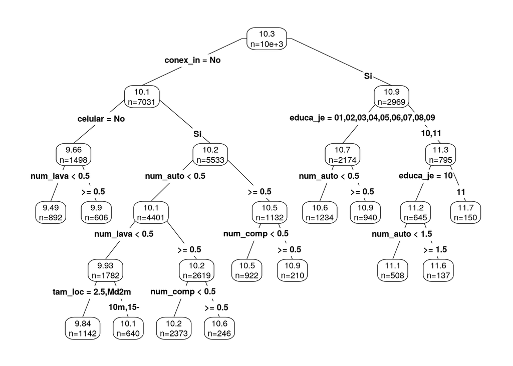

```r
library(rpart)
library(rpart.plot)

arbol_grande <- rpart(ingreso_log ~ tam_loc + educa_jefe +
      celular+ conex_inte + num_auto+ num_tosta+ num_lavad+ num_compu + factor,
      data= datos, cp=0)
prp(prune(arbol_grande, cp=0.004), type=4, extra=1, digits=3)
```

1. ¿Qué significa la información que hay en cada nodo? Nota: puedes interpretar diferencias de log ingreso rápidamente si tomas en cuenta que una diferencia en la escala logarítmica (para diferencias más chicas) es aproximadamente cambio porcentual en ingreso. Por ejemplo la diferencia de ingreso en escala log de 4.7 a 4.9 es aproximadamente un incremento de 20%.

```r
summary(arbol_grande$frame)
```

```
##          var            n                  wt                dev
##  <leaf>    :850   Min.   :    7.00   Min.   :    7.00   Min.   :   0.124
##  factor    :600   1st Qu.:   11.00   1st Qu.:   11.00   1st Qu.:   2.710
##  educa_jefe:117   Median :   19.00   Median :   19.00   Median :   5.463
##  tam_loc   : 65   Mean   :   81.47   Mean   :   81.47   Mean   :  30.390
##  num_compu : 21   3rd Qu.:   48.00   3rd Qu.:   48.00   3rd Qu.:  15.010
##  num_tosta : 19   Max.   :10000.00   Max.   :10000.00   Max.   :6223.501
##  (Other)   : 27
##       yval          complexity           ncompete        nsurrogate
##  Min.   : 8.758   Min.   :0.0000000   Min.   :0.0000   Min.   :0.000
##  1st Qu.: 9.939   1st Qu.:0.0000000   1st Qu.:0.0000   1st Qu.:0.000
##  Median :10.275   Median :0.0000000   Median :0.0000   Median :0.000
##  Mean   :10.311   Mean   :0.0003301   Mean   :0.9564   Mean   :0.352
##  3rd Qu.:10.669   3rd Qu.:0.0001360   3rd Qu.:2.0000   3rd Qu.:0.000
##  Max.   :12.477   Max.   :0.2115832   Max.   :4.0000   Max.   :5.000
##
```

2. Poda el árbol para mostrar solamente un árbol con 5 nodos terminales. Evalúa el error de entrenamiento para este árbol.

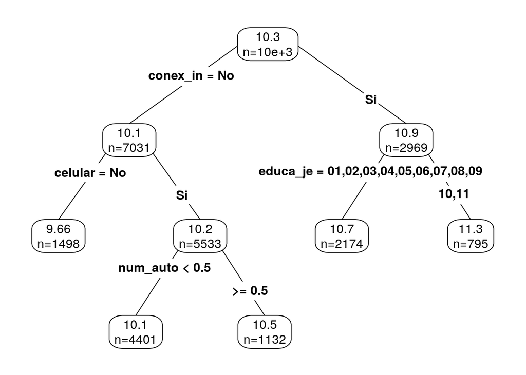

```r
arbol_peq <- prune.rpart(arbol_grande, cp = 0.014652129)
prp(arbol_peq, type = 4, extra = 1, digits = 3)
```

*Error de entrenamiento*

Error Promedio

```r
preds_peq <- predict(arbol_peq, newdata = datos)
preds_gde <- predict(arbol_grande, newdata = datos)
paste("Promedio de errores árbol pequeño:",
      mean(abs(preds_peq-datos$ingreso_log)))
```

```
## [1] "Promedio de errores árbol pequeño: 0.499914172710061"
```

```r
paste("Promedio de errores árbol grande: ",
      mean(abs(preds_gde-datos$ingreso_log))
)
```

```
## [1] "Promedio de errores árbol grande:  0.401303174417545"
```

Error RSS

```r
rss_calc <- function(dat, y_hat) {
  y <- dat$ingreso_log
  e <- (y - y_hat)
  rss <- sum(e^2)
  0.5*rss
}
rss_peq <- rss_calc(datos, preds_peq)
rss_gde <- rss_calc(datos, preds_gde)
paste("Error RSS árbol pequeño:",
      rss_peq)
```

```
## [1] "Error RSS árbol pequeño: 2098.27014161647"
```

```r
paste("Error RSS árbol grande: ",
      rss_gde)
```

```
## [1] "Error RSS árbol grande:  1363.83380963075"
```

*Además hice pruebas jugando con el valor de `Costo Computacional (CP)` y obviamente no varía mucho en la predicción, como era de esperarse, siempre y cuando se mantengan el mismo número de nodos terminales.*

### Bosques aleatorios

```r
#utiliza estos datos, que tienen las variables categóricas convertidas a factores.
datos_df <- data.frame(unclass(datos))
```

1. Usa un bosque aleatorio para predecir el log ingreso. Prueba algunos valores de $m$ (mtry) y escoge un modelo final usando el error out-of-bag. Grafica cómo evoluciona la estimación OOB del error conforme aumenta el número de árboles.

*Creación de los 3 modelos:*

```r
bosque_3 <- randomForest(ingreso_log ~ tam_loc + educa_jefe + celular+ conex_inte +
    num_auto + num_tosta+ num_lavad+ num_compu + factor, data = datos_df,
    ntree = 1500, mtry = 3, importance = T)
bosque_6 <- randomForest(ingreso_log ~ tam_loc + educa_jefe + celular+ conex_inte
    + num_auto + num_tosta+ num_lavad+ num_compu + factor, data = datos_df,
    ntree = 1500, mtry = 6, importance = T)
bosque_9 <- randomForest(ingreso_log ~ tam_loc + educa_jefe + celular+ conex_inte
    + num_auto + num_tosta+ num_lavad+ num_compu + factor, data = datos_df,
    ntree = 1500, mtry = 9, importance = T)
```

*Errores RSS*

```r
preds_3 <- predict(bosque_3, data = datos_df, type = 'response')
preds_6 <- predict(bosque_6, data = datos_df, type = 'response')
preds_9 <- predict(bosque_9, data = datos_df, type = 'response')

rss_3 <- rss_calc(datos, preds_3)
rss_6 <- rss_calc(datos, preds_6)
rss_9 <- rss_calc(datos, preds_9)
c(c("", "m=3", "m=6", "m=9"),c("RSS", rss_3, rss_6, rss_9))
```

```
## [1] ""                 "m=3"              "m=6"
## [4] "m=9"              "RSS"              "1804.94872627676"
## [7] "1948.3402382508"  "2066.28081784685"
```

*Graficación de los errores out-of-bag*

```r
# rm(preds_3, preds_6, preds_9) # sólo para fines de clarificación y limpieza de código
errores_rf <- NULL
errores_rf$ntrees <- 1:length(bosque_3$mse)
errores_rf$bosque_3 <- bosque_3$mse
errores_rf$bosque_6 <- bosque_6$mse
errores_rf$bosque_9 <- bosque_9$mse
summary(as.data.frame(errores_rf))
```

```
##      ntrees          bosque_3         bosque_6         bosque_9
##  Min.   :   1.0   Min.   :0.3609   Min.   :0.3896   Min.   :0.4132
##  1st Qu.: 375.8   1st Qu.:0.3610   1st Qu.:0.3898   1st Qu.:0.4135
##  Median : 750.5   Median :0.3610   Median :0.3899   Median :0.4136
##  Mean   : 750.5   Mean   :0.3619   Mean   :0.3919   Mean   :0.4155
##  3rd Qu.:1125.2   3rd Qu.:0.3613   3rd Qu.:0.3906   3rd Qu.:0.4138
##  Max.   :1500.0   Max.   :0.4441   Max.   :0.5589   Max.   :0.6363
```

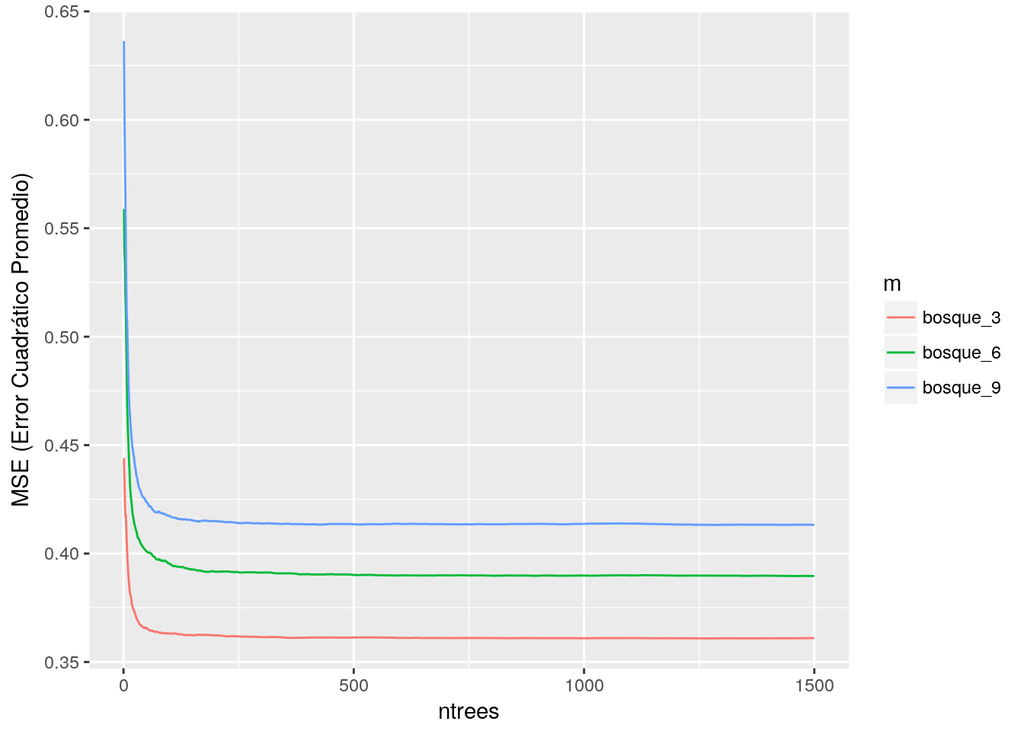

```r
errores_rf <- as.data.frame(errores_rf) %>%
  gather(metric, value, -ntrees)
ggplot(errores_rf, aes(x=ntrees, y = value, colour = metric)) + geom_line() +
  labs(y = "MSE (Error Cuadrático Promedio)", colour = "m")
```

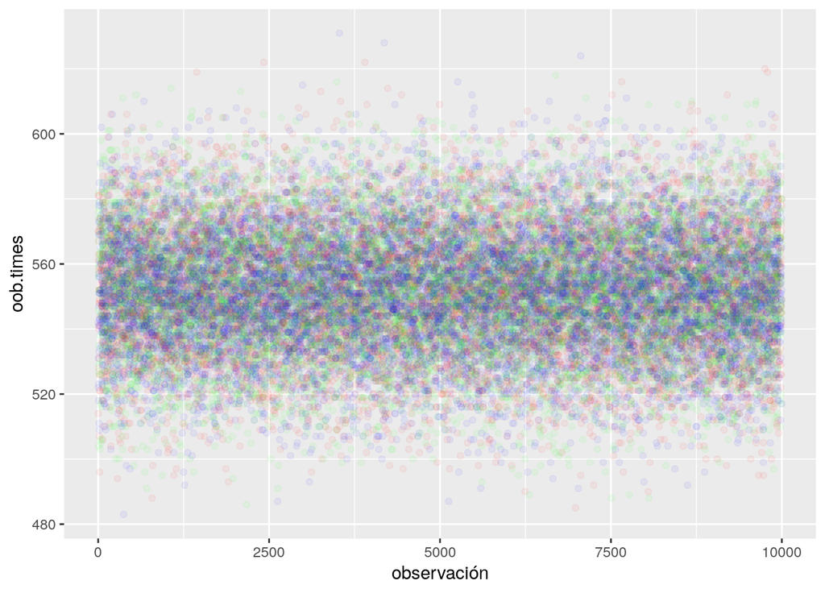

```r
ggplot() +
  geom_point(aes(x = 1:length(bosque_3$oob.times), y = bosque_3$oob.times), alpha = 0.05, color="red") +
  geom_point(aes(x = 1:length(bosque_6$oob.times), y = bosque_6$oob.times), alpha = 0.05, color="green") +
  geom_point(aes(x = 1:length(bosque_9$oob.times), y = bosque_9$oob.times), alpha = 0.05, color="blue") +
  labs(y = "oob.times", x = "observación", col = "Colores")
```

2. Examina las importancias de las variables. ¿Cuáles son las 3 variables más importantes?

```r
head(names(importance(bosque_3)[,1]), n=3)
```

```
## [1] "tam_loc"    "educa_jefe" "celular"
```

```r
imp3 <- as.data.frame(importance(bosque_3))
imp3$variable <- rownames(importance(bosque_3))
imp6 <- as.data.frame(importance(bosque_6))
imp6$variable <- rownames(imp6)
imp9 <- as.data.frame(importance(bosque_9))
imp9$variable <- rownames(imp9)
imp <- imp3 %>% inner_join(imp6, by = "variable") %>%
  inner_join(imp9, by = "variable")
names(imp) <- c("MSE m=3", "Pureza m=3", "Variable",
      "MSE m=6", "Pureza m=6",
      "MSE m=9", "Pureza m=9"
      )
imp <- imp %>% select(c("Variable",
        "MSE m=3", "MSE m=6", "MSE m=9",
        "Pureza m=3", "Pureza m=6", "Pureza m=9"
      ))
rm(imp3,imp6,imp9)
head(imp, n=3)
```

```
##     Variable   MSE m=3   MSE m=6  MSE m=9 Pureza m=3 Pureza m=6 Pureza m=9
## 1    tam_loc  80.37011  92.78822 85.50595   200.8568   265.4337   290.9324
## 2 educa_jefe 104.50603 100.68479 87.83994   519.7746   613.8181   719.1620
## 3    celular 120.20660  90.99002 81.49766   256.8351   305.6083   345.3811
```

3. Incluye una o dos variables adicionales que crees que puedan tener importancia alta. ¿En qué lugar aparecen?

```r
tail(names(importance(bosque_3)[,1]), n=6)
```

```
## [1] "conex_inte" "num_auto"   "num_tosta"  "num_lavad"  "num_compu"
## [6] "factor"
```

*Estos son sus valores*

```r
tail(imp, n=6)
```

```
##     Variable   MSE m=3   MSE m=6   MSE m=9 Pureza m=3 Pureza m=6
## 4 conex_inte 140.82046 109.46607  88.86263  674.18291   967.8755
## 5   num_auto 139.46153 129.93273 124.11825  470.60150   421.2133
## 6  num_tosta  37.81807  27.70831  22.38736   92.03853   105.1230
## 7  num_lavad 101.98554  74.57255  72.41704  302.09339   259.2811
## 8  num_compu  83.92444  64.10832  60.50643  529.64210   485.7684
## 9     factor  46.77205  67.67087  61.27283  537.07455  1610.8570
##   Pureza m=9
## 4  1316.4467
## 5   358.4410
## 6   108.7280
## 7   232.6894
## 8   184.4079
## 9  2076.2109
```